# Combinação de Variáveis Aleatórias

## Gabarito

Carregando algumas bibliotecas:

```python
%matplotlib inline
import pandas as pd
import matplotlib.pyplot as plt
import numpy as np

from scipy import stats
import math

# Para ter melhor print
from IPython.display import display
```

## Índice

- Questão 1 - Escola Infantil "Papai Sem-Noção"
  - Item a
  - Item b
  - Item c
- Questão 2 - Transmissão de Dados
  - Item a
  - Item b
  - Item c
- Questão 3 - Análise de Energia Solar
  - Item a
  - Item b
- Questão 4
  - Item a
  - Item b
  - Item c
- Questão 5 - AI e AF

# Questão 1

Na escola infantil "Papai Sem-Noção" eles fazem coisas diferentes. No encerramento do ano vão fazer uma eco-aventura: cada dupla pai-e-filho vai descer um rio de bote inflável.

O peso dos pais pode ser modelado como uma variável aleatória normal de média $85$ kg e desvio padrão $10$ kg. O peso dos filhos pode ser modelado como uma variável normal de média $20$ kg e desvio padrão $4$ kg. Existe uma correlação entre o peso do pai e o peso do filho igual a $0,5$

**a)** Nas condições acima, a média e o desvio-padrão do peso da dupla pai-e-filho são, respectivamente, $105$ kg e $12,5$ kg. Como esses valores foram obtidos? Justifique com cálculos numéricos.

```python
#Resposta
```

```python
mu_pai = 85
sigma_pai = 10
mu_filho = 20
sigma_filho = 4
rho = 0.5

# Media.
mu_dupla = mu_pai + mu_filho
print(mu_dupla)

# Variancia.
var_pai = sigma_pai ** 2
var_filho = sigma_filho ** 2
cov_pai_filho = rho * sigma_pai * sigma_filho
var_dupla = var_pai + var_filho + 2 * cov_pai_filho

sigma_dupla = np.sqrt(var_dupla)
print(sigma_dupla)
```

```
105
12.489995996796797
```

**b)** A escola vai comprar botes infláveis para descer o rio. Existem dois modelos:

- "Carpe Diem": cabe duas pessoas, com peso total entre $80$ kg e $115$ kg.
- "Memento Mori": cabe duas pessoas, com peso total entre $95$ kg e $120$ kg.

Qual dos dois modelos é mais adequado para a escola? Ou seja, em qual dos modelos a chance de comportar um par pai-e-filho é maior? Calcule essas chances para os dois modelos e compare.

```python
#Resposta
cdf = lambda x: stats.norm.cdf(x, loc=mu_dupla, scale=sigma_dupla)
p_carpe = cdf(115) - cdf(80)
p_memento = cdf(120) - cdf(95)

p_carpe, p_memento
```

```
(0.7656663981697922, 0.6734470439782092)
```

**c)** O diretor, o sr. Joselito, teve uma ideia "brilhante": se eles colocarem "lastro" (um peso extra) nos botes para complementar o peso da dupla, eles conseguem expandir a faixa de peso util do barco.

Com isso, o limite mínimo de peso dos barcos "Memento Mori" será compensado pelo "lastro", mas o peso total máximo ainda é de $120$ kg. Calcule o novo valor do limite inferior que permita que $85\%$ das duplas pai-e-filho participem do evento nos botes "Memento Mori".

Recapitulando:

- O limite superior de 120 kg não tem como mudar (é fixo).
- O limite mínimo é livre (já que podemos usar lastro para compensar o peso de duplas muito leves).
- Queremos saber qual limite mínimo que permita que $85\%$ das duplas pai-e-filho participem do evento nos botes "Memento Mori".

```python
p_abaixo_120 = stats.norm.cdf(120, loc=mu_dupla, scale=sigma_dupla)
p_abaixo_critico = p_abaixo_120 - 0.85
peso_critico = stats.norm.ppf(p_abaixo_critico, loc=mu_dupla, scale=sigma_dupla)
peso_critico
```

```
82.38810723621216
```

# Questão 2

## Transmissão de dados

Em um certo sistema de transmissão de dados, uma informação digital é transmitida na forma de um sinal elétrico onde uma voltagem constante de $5 V$ representa o bit $1$ e uma voltagem de $0 V$ representa o bit $0$.

O sinal é gerado perfeitamente no ponto de transmissão; porém ao longo do caminho do sinal surgem várias interferências elétricas externas e também ruído térmico na linha de transmissão. Consequentemente, o sinal no receptor é igual ao sinal transmitido ($5 V$ para bit $1$ e $0 V$ para bit $0$) mais uma componente de ruído.

No receptor o sinal é observado por um breve instante, e o valor de voltagem medido é comparado a um valor de referência de $3,0 V$ para decidir qual será o valor do bit *recebido*. Ou seja, se a voltagem recebida for maior que $3,0 V$, o bit é considerado $1$; caso contrário é bit $0$.

Com esse cenário nota-se que podem haver erros de transmissão. Por exemplo: se um bit $1$ for enviado, mas o ruido aleatório for de $-2,5 V$, o sinal recebido será $5 + (-2,5) = 2,5 V$, abaixo do limiar de decisão $3,0$, e portanto será identificado erroneamente como bit $0$.

Os engenheiros investigaram o ruído e concluiram que este pode ser modelado como uma variável aleatória com distribuição normal de média $0 V$ e desvio padrão $0,9 V$. Ou seja:

- O ruido é modelado por $\eta \sim N(\mu = 0, \sigma^2 = 0,81)$
- Quando um bit $0$ é enviado, o sinal elétrico que chega no receptor é $X_0 = 0 + \eta$
- Quando um bit $1$ é enviado, o sinal elétrico que chega no receptor é $X_1 = 5 + \eta$

**a)** Qual a probabilidade de que um bit $0$ transmitido seja detectado como um bit $1$? E qual a probabilidade de que um bit $1$ transmitido seja detectado como bit $0$ no receptor?

```python
p_1_dado_0 = 1 - stats.norm.cdf(3, loc=0, scale=0.9)
p_0_dado_1 = stats.norm.cdf(3, loc=5, scale=0.9)
p_1_dado_0, p_0_dado_1
```

```
(0.0004290603331967846, 0.013134145691021117)
```

**b)** Supondo que a probabilidade de transmissão de um bit $0$ seja de $60 \%$ qual a probabilidade de um erro de bit na transmissão?

```python
p_0 = 0.6
p_1 = 1 - p_0
p_erro = p_1_dado_0 * p_0 + p_0_dado_1 * p_1
p_erro
```

```
0.0055110944763265175
```

**c)** Qual a probabilidade de que ocorram $3$ erros de bit em um pacote de $4$ bits transmitidos (com probabilidade $60\%$ de transmissão de bit $0$)?

```python
p_3_erros = stats.binom.pmf(3, n=4, p=p_erro)
p_3_erros
```

```
6.658455511599444e-07
```

# Questão 3

## Análise de Energia Solar

Sabe-se que a radiação solar ($Rad$) está distribuída no Brasil de acordo com uma curva normal $Rad \sim N(\mu=150, \sigma=50)$.

Uma empresa fabrica painéis solares que têm sua eficiência distribuída de acordo com uma curva normal: $\eta \sim N(\mu=0.4, \sigma=0.15)$. A potência disponível em determinada residência é chamada de potência útil ($P_{útil}$), e é o resultado da eficiência energética do painel solar adquirido e também da radiação solar disponível. Ou seja, $P_{útil} = \eta \times Rad$

**a.** Construa, via simulação, a distribuição de $P_{útil}$. Apresente o histograma resultante:

```python
tamanho = 100000
ef = stats.norm.rvs(loc=0.40, scale=0.15, size=tamanho)
rad = stats.norm.rvs(loc=150, scale=50, size=tamanho)
```

```python
Putil = ef*rad
```

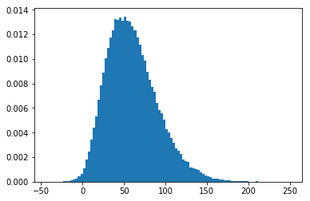

```python
plt.hist(Putil, density=True, bins=100);
```

```python
np.percentile(Putil, 5)
```

```
16.225566373262833
```

**b.** A empresa de painéis solares garantiu que, se a potência útil instalada na casa dos clientes é menor que $15W/m^2$, vai pagar uma indenização. Qual a porcentagem dos clientes que vai ganhar indenização?

**Resposta - Método 1:**

```python
stats.percentileofscore(Putil,15)
```

```
4.395
```

**Resposta - Método 2:**

```python
len(Putil[Putil < 15])/len(Putil)
```

```
0.04395
```

**Resposta - Método 3:**

```python
putil_series = pd.Series(Putil)
```

```python
len(putil_series[putil_series < 15])/len(putil_series)
```

```
0.04395
```

**Resposta - Método 4:**

```python
cnt = 0
for x in Putil:
    if x < 15:
        cnt += 1
print(cnt/len(Putil))
```

```
0.04395
```

# Questão 4

[figure not shown]

Seja $U$ uma variável aleatória que segue uma distribuição uniforme no intervalo $[3.0,6.0]$

Seja $Y\sim N(4.5, \sigma^2=9)$

Seja também a variável aleatória $\overline{U}$, calculada como a média de amostras de $U$ feitas com $n$ elementos independentes entre si. Assuma $n=50$.

Nota que a variável $\overline{U}$ **não** é mostrada no gráfico.

Vamos montar a variável aleatória $W$ :

$$W = 2\overline{U} + 3Y$$

**Responda:**

Deixe os cálculos, não coloque os valores apenas

```python
from scipy.stats import uniform
from scipy.stats import norm
import numpy as np
import pandas as pd
import seaborn as sns
import matplotlib.pyplot as plt
import math

## Os plots não são exigidos. Apenas nos ajudam a visualizar o problema
eixo_horizontal = np.linspace(0,10,800)
# U: uniforme entre 4 a 7
a = 3
b = 6
loc_unif = a
scale_unif = b - a
pdf_U = uniform.pdf(eixo_horizontal, loc=loc_unif, scale=scale_unif)

# Y: normal N(4.5, var=8)
mu_y = 4.5
scale_y = 3
var_y = scale_y**2
pdf_Y = norm.pdf(eixo_horizontal, loc=mu_y, scale=scale_y)
```

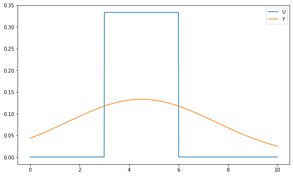

```python
plt.figure(figsize=(10,6))
plt.plot(eixo_horizontal, pdf_U, label="U")
#plt.legend("U")
plt.plot(eixo_horizontal, pdf_Y, label = "Y")
plt.legend()
```

**a)** Quanto vale $E(\overline{U})$ e $Var(\overline{U})$ ?

$E(\overline{U})=\frac{a+b}{2} = 4.5$

$V(\overline{U}) = 0.015$

```python
EU_ = (a+b)/2
```

```python
Var_U = (b-a)**2/12
Var_U
```

```
0.75
```

```python
n=50
Var_U_ = Var_U/n
```

```python
dp_U_ = math.sqrt(Var_U_)
```

```python
EU_, Var_U_, dp_U_
```

```
(4.5, 0.015, 0.1224744871391589)
```

**b)** Quanto vale $E(W)$ e $Var(W)$?

Vamos calcular agora $E(W)$ e $V(W)$:

$E(W) = E(2\overline{U} + 3Y)$

```python
E_W = 2*EU_+3*mu_y
```

```python
E_W
```

```
22.5
```

```python
Var_W=4*Var_U_ + 9*var_y
Var_W
```

```
81.06
```

```python
dp_W = math.sqrt(Var_W)
dp_W
```

```
9.003332716277901
```

**c)** Quanto vale $P(W \geq 10| W < E(W))$ ?

- Sabemos que $E(W)=22.5$

$P(W \geq 10| W < E(W)) = P(W \geq 10| W < 22.5) = \dfrac{P(10 \leq W < 22.5)}{P(W < 22.5)}$

Sabemos que $\overline{U}$ é normal por causa do TLC, e que $W$ é normal pelo princípio da reprodutibilidade das normais, porque $\overline{U}$ e $Y$ são normais.

Portanto:

$$W\sim N(\mu=22.5, \sigma^{2}=81.06)$$

```python
eixo_x = np.linspace(E_W - 3.5*dp_W, E_W + 3.5*dp_W, 1000)
```

```python
# Plot de W
# Não precisa plotar o gráfico
pdf_W = norm.pdf(eixo_x, loc=E_W, scale=dp_W)
```

```python
limiar = 10
```

### Área de $P(10 \leq W < 22.5)$

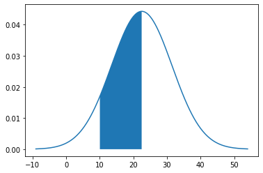

```python
plt.plot(eixo_x, pdf_W)
plt.fill_between(eixo_x, pdf_W, where=(eixo_x>limiar)& (eixo_x<E_W))
```

### Área de $P(W < 22.5)$

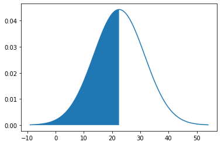

```python
plt.plot(eixo_x, pdf_W)
plt.fill_between(eixo_x, pdf_W, where=eixo_x<E_W)
```

```python
prob_menor_10 = norm.cdf(limiar, loc=E_W, scale=dp_W)
```

```python
prob_menor_20 = norm.cdf(E_W, loc=E_W, scale=dp_W)
```

```python
prob_entre_10_20 = prob_menor_20 - prob_menor_10
```

```python
prob_maior_10_dado_menor_media = prob_entre_10_20/prob_menor_20
```

$P(W \geq 10| W < E(W))$

```python
prob_maior_10_dado_menor_media
```

```
0.8349770454159595
```

# Questão 5

A Avaliação Intermediária de Ciência dos dados teve média 4.25 e desvio padrão 1.70.

A Avaliação Final está acontecendo agora, nesse momento, porém assuma que essa avaliação terá média igual 7.75 e desvio padrão igual 2.20.

Assuma também que ambas avaliações tenham notas com correlação de 0.35 e que qualquer combinação linear entre essas notas seja modelada por uma distribuição normal.

**Calcule a probabilidade de um aluno qualquer ter as notas das avaliações somando pelo menos 10 pontos. Discuta o que representa esse resultado.**

```python
#Informações do enunciado
media_AI = 4.25
dp_AI = 1.70

media_AF = 7.75
dp_AF = 2.20

Corr = 0.35
```

**Resposta:**

```python
media_soma = media_AI + media_AF
var_soma = dp_AI**2 + dp_AF**2 + 2*dp_AI*dp_AF*Corr

1-stats.norm.cdf(10, loc=media_soma, scale=var_soma**0.5)
```

```
0.7329402712997912
```